# Importing, Tidying, and Tranforming Data

## Series On: Data Wrangling and Visualization in R

## Session 1: Importing Data, Data Wrangling, and Tidy Data

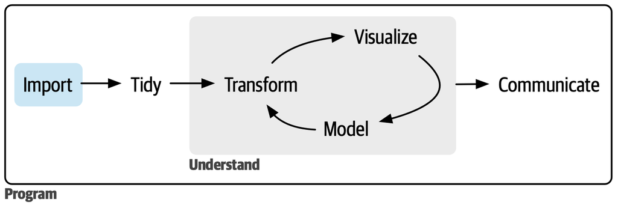

# Objectives of today’s session

1. Learn how to import raw data in R.
2. Creat tidy dataset from raw data using `tidyr`.
3. Use `dplyr` package for data transformation.

# R is a simple calculator

| Operator | Description |
| --- | --- |
| **+** | Addition |
| **-** | Subtraction |
| * | Multiplication |
| **/** | Division |
| **^** | Exponentiation (Power) |
| **%%** | Modulus (Remainder) |
| **%/%** | Integer Division (Quotient) |

```r
398 + 783
```

```
## [1] 1181
```

```r
600 / 5
```

```
## [1] 120
```

```r
45 * 45
```

```
## [1] 2025
```

### **Exercise:1**

1. Try doing following calculation using math operators

$$\frac{1+5^{1/2}} {2}$$

```r
# Your code here
```

2. Find modulus of 5 divided by 2

```r
# Your code here
```

# R scripts write, organize, and execute code in the R

create a new script file (File > New File > R Script)

```r
## Copy this code in the R script

# Assigning numbers to variables
a <- 5
b <- 3

# Addition
sum_result <- a + b

# Subtraction
diff_result <- a - b

# Print the results
print("Results of Basic Math Operations:")
```

```
## [1] "Results of Basic Math Operations:"
```

```r
print(paste("Sum: ", sum_result))
```

```
## [1] "Sum:  8"
```

```r
print(paste("Difference: ", diff_result))
```

```
## [1] "Difference:  2"
```

# Data Types and Objects in R

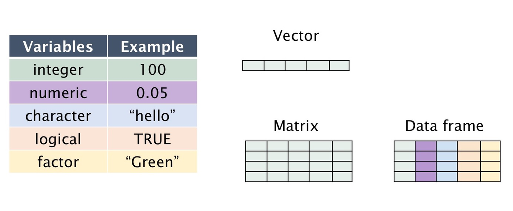

```r
num_variable <- 42.5
class(num_variable)
```

```
## [1] "numeric"
```

```r
char_variable = "Welcome to the DS club"
class(char_variable)
```

```
## [1] "character"
```

```r
logic_variable = TRUE
class(logic_variable)
```

```
## [1] "logical"
```

```r
num_variable == 42.5
```

```
## [1] TRUE
```

```r
num_variable >= 50
```

```
## [1] FALSE
```

```r
class(num_variable == 42.5)
```

```
## [1] "logical"
```

## Non Atomic R Objects

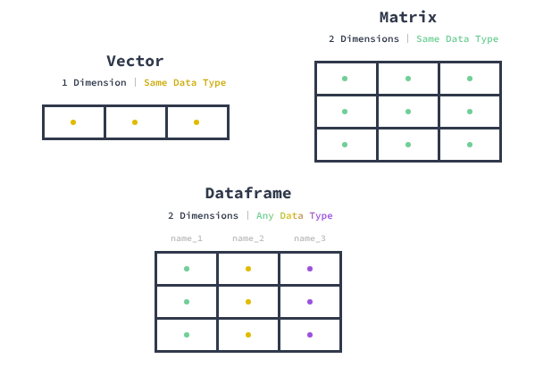

**Objects Can Contain Multiple Data Types**

How do we create a vector.

```r
numeric_vector_1 <- c(1, 2, 3, 4, 5)

numeric_vector_2 <- 1:5
```

Accessing elements of a numeric vector

```r
numeric_vector_1[3] # Access the third element of the vector
```

```
## [1] 3
```

```r
numeric_vector_1[2:3] # Access the second to third element of the vector
```

```
## [1] 2 3
```

```r
numeric_vector_1[c(2,5)] # Access the second and fifth element of the vector
```

```
## [1] 2 5
```

Data Frames are important R objects. We will learn how to create a dataframe later in this session.

### **Exercise:3**

1. Create a vector of odd numbers till 10 and access numbers greater than 5

```r
# Your code here
```

# Functions: Block of reusable code that performs a tasks

3 Key Properties of an R function.

- functions have a name and they are case sensetive
- following the name they have a pair of ()
- inside (), function take 0 or more arguments

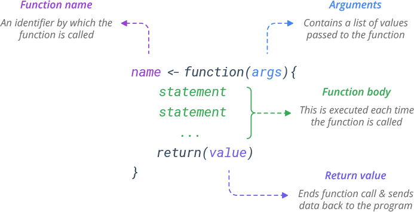

**Why did the function go to therapy? It had too many issues with its arguments!**

```r
summ_two_numbers <- function(a=3, b=6){
  return(a+b)
}

summ_two_numbers()
```

```
## [1] 9
```

```r
summ_two_numbers(5, 19)
```

```
## [1] 24
```

### **Exercise:2**

Complete this code to return square of 9

```r
# Your code here
squared_num <- function(x){
   squared = ___
   return(___)
 }

 squared_num(9)
```

# Read tables in R

Need help looking at the many arguments of `read.table` you can use? It’s easy.

**Type this on the console:** `?read.table`

Don’t know what your file looks like? No issue. We can check by reading the file line by line. This works even when the file size in GBs and we don’t have a software to open the file on our operating system.

```r
# Specify the path to your file
file_path1 <- "Datasets/file_1_to_read.txt"

# Read the first few lines
readLines(file_path1, n = 5)
```

```
## [1] "Geneid\tCounts" "497097\t0"      "100503874\t0"   "100038431\t0"
## [5] "19888\t0"
```

*Note: You can not create a R dataframe and perform data analysis by reading a file line by line.*

```r
df1 = read.table(file_path1, sep="\t", header = TRUE)
```

To check if your data was properly read

```r
df1
```

```
##       Geneid Counts
## 1     497097      0
## 2  100503874      0
## 3  100038431      0
## 4      19888      0
## 5      20671      0
## 6      27395    679
## 7      18777   1119
## 8  100503730      6
## 9      21399   1485
## 10     58175      2
## 11    108664   2037
## 12     18387      0
## 13    226304      0
## 14     12421   1004
```

[output cut: 18 more lines]

```r
head(df1) # Another way to check a long table (Prints top 6 rows)
```

```
##      Geneid Counts
## 1    497097      0
## 2 100503874      0
## 3 100038431      0
## 4     19888      0
## 5     20671      0
## 6     27395    679
```

### **Exercise 4**

```r
# Specify the path to your file
file_path2 <- "Datasets/file_2_to_read.txt"
```

1. Try figuring out what are the best arguments to read the second file

```r
# Hint: Read the first few lines
readLines(,)
```

2. Now use read.table function to create the df2

```r
# Complete the code
df2 = read.table(file_path2, , )

df2
```

# Installing and Loading Libraries

All packages are installed in this environment.

If you will use RStudio on your own machine you will have to install packages before you can install using the following command.

```r
install.packages("dplyr")
```

To load a library in your environment, use the `library` command.

```r
library(readr)
read_csv("Datasets/file_3_to_read.csv", col_select = c(1:4))
```

```
## # A tibble: 8 × 4
##     `1`   `2`   `3`   `4`
##   <dbl> <dbl> <dbl> <dbl>
## 1     2     3     4     5
## 2     3     4     5     6
## 3     4     5     6     7
## 4     5     6     7     8
## 5     6     7     8     9
## 6     7     8     9    10
## 7     8     9    10    11
## 8     9    10    11    12
```

```r
read_csv("Datasets/file_3_to_read.csv", col_select = c(4:9))
```

```
## # A tibble: 8 × 6
##     `4`   `5`   `6`   `7`   `8`   `9`
##   <dbl> <dbl> <dbl> <dbl> <dbl> <dbl>
## 1     5     6     7     8     9    10
## 2     6     7     8     9    10    11
## 3     7     8     9    10    11    12
## 4     8     9    10    11    12    13
## 5     9    10    11    12    13    14
## 6    10    11    12    13    14    15
## 7    11    12    13    14    15    16
## 8    12    13    14    15    16    17
```

```r
library(readxl)
read_xlsx("Datasets/file_4_to_read.xlsx", sheet = 'Sheet1')
```

```
## # A tibble: 32 × 2
##       Geneid Counts
##        <dbl>  <dbl>
##  1    497097      0
##  2 100503874      0
##  3 100038431      0
##  4     19888      0
##  5     20671      0
##  6     27395    679
##  7     18777   1119
##  8 100503730      6
##  9     21399   1485
## 10     58175      2
## # ℹ 22 more rows
```

# Tidying data with `tidyr` package

**Tidy data** is a standard way of **mapping** the **meaning** of a dataset to its **structure**.

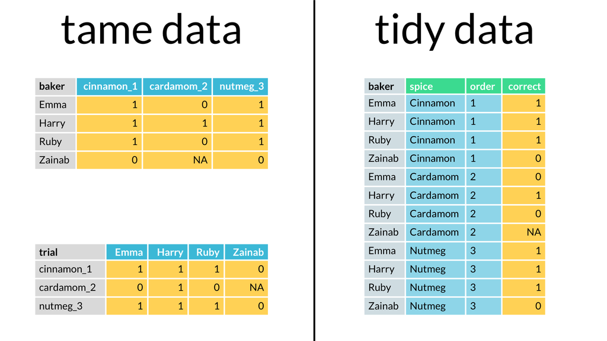

What’s a tidy data

### **Exercise 5**

1. load `tidyr` package

```r
# Complete the following code

library(_ _ _)
```

2. load `dplyr` package

```r
# Write the line to load dplyr package
```

## Split and Merge Messy Data

```r
# Let's create sample dataframe and look at some tidyr functions to merge and split data

splicing_data <- data.frame(
  Event_ID = c('ENSG1_AB',
               'ENSG2_CD',
               'ENSG3_EF',
               'ENSG4_GH',
               'ENSG5_IJ'),
  PSI_value_1 = as.character(c('0.', '0.', '0.', '0.', '1.')),
  PSI_value_2 = as.character(c(1,2,3,4,0)),
  Group = c("A", "B", "B", "A", "A"),
  Peak = c('NA', 5, "NA", 9, 'NA')
)

splicing_data
```

```
##   Event_ID PSI_value_1 PSI_value_2 Group Peak
## 1 ENSG1_AB          0.           1     A   NA
## 2 ENSG2_CD          0.           2     B    5
## 3 ENSG3_EF          0.           3     B   NA
## 4 ENSG4_GH          0.           4     A    9
## 5 ENSG5_IJ          1.           0     A   NA
```

```r
tidy_splicing_data <- tidyr::unite(splicing_data, PSI_value_1, PSI_value_2, col="PSI_value", sep="", remove=TRUE)

tidy_splicing_data
```

```
##   Event_ID PSI_value Group Peak
## 1 ENSG1_AB       0.1     A   NA
## 2 ENSG2_CD       0.2     B    5
## 3 ENSG3_EF       0.3     B   NA
## 4 ENSG4_GH       0.4     A    9
## 5 ENSG5_IJ       1.0     A   NA
```

```r
# return new dataframe with new defined column
# also we can remove old columns or retain them
# you could play with "sep" and "col" arguments
```

```r
# tidyr::separate same as tidyr::separate_wider_delim
tidyr::separate(tidy_splicing_data, Event_ID, sep="_", into=c('ID', 'Splicing event'), remove=TRUE)
```

```
##      ID Splicing event PSI_value Group Peak
## 1 ENSG1             AB       0.1     A   NA
## 2 ENSG2             CD       0.2     B    5
## 3 ENSG3             EF       0.3     B   NA
## 4 ENSG4             GH       0.4     A    9
## 5 ENSG5             IJ       1.0     A   NA
```

### **Exercise 6**

Work with another dataset.

1. Import the data into R..

*Hint: Its a Tab Separated file*

```r
# Complete the code here
path <- "Datasets/gff_file.txt"
df3 <- read.table(path, )
```

2. Select column `c(1,3,4,5, and 9)`.

*Hint: Check Base R cheat sheet*

```r
# Your the code here
```

3. Separate column 9 by `sep=";"` and remove the last two columns.

*Hint: Its the same as selecting the first 5 columns*

```r
# Complete the code here
tidyr::select(df3, )
```

# Reshape data with `tidyr`

pivot_longer and pivot_wider

```r
# First of all, let's create sample dataframe.

table2 <- data.frame(
  country = c("A", "A", "B", "B", "C", "C"),
  year = c(1999, 2000, 1999, 2000, 1999, 2000),
  cases = c("0.7K", "2K", "37K", "80K", "212K", "213K"),
  pop = c("19M", "20M", "172M", "174M", "1T", "1T")
)

table2
```

```
##   country year cases  pop
## 1       A 1999  0.7K  19M
## 2       A 2000    2K  20M
## 3       B 1999   37K 172M
## 4       B 2000   80K 174M
## 5       C 1999  212K   1T
## 6       C 2000  213K   1T
```

```r
# Let's reshape it
tidyr::pivot_longer(table2, cols = c("cases","pop"), names_to = "type", values_to = "count")
```

```
## # A tibble: 12 × 4
##    country  year type  count
##    <chr>   <dbl> <chr> <chr>
##  1 A        1999 cases 0.7K
##  2 A        1999 pop   19M
##  3 A        2000 cases 2K
##  4 A        2000 pop   20M
##  5 B        1999 cases 37K
##  6 B        1999 pop   172M
##  7 B        2000 cases 80K
##  8 B        2000 pop   174M
##  9 C        1999 cases 212K
## 10 C        1999 pop   1T
## 11 C        2000 cases 213K
## 12 C        2000 pop   1T
```

# Transforming with `dplyr`

| dplyr Verb | What it Does |
| --- | --- |
| `filter` | Retrieve rows based on specified values. |
| `select` | Retrieve columns based on specified names. |
| `mutate` | Add new variables to the data frame. |
| `arrange` | Change the order of the rows based on variables. |

Let’s look at how those work.

```r
table2
```

```
##   country year cases  pop
## 1       A 1999  0.7K  19M
## 2       A 2000    2K  20M
## 3       B 1999   37K 172M
## 4       B 2000   80K 174M
## 5       C 1999  212K   1T
## 6       C 2000  213K   1T
```

In our table the cases is a character data type. To perform any mathematical operations or comparisons. We must mutate this into an appropriate double.

```r
table3 <- mutate(table2, cases = as.double(sub("K", "", cases))*1000)

table3
```

```
##   country year  cases  pop
## 1       A 1999    700  19M
## 2       A 2000   2000  20M
## 3       B 1999  37000 172M
## 4       B 2000  80000 174M
## 5       C 1999 212000   1T
## 6       C 2000 213000   1T
```

Now we can use filter to look for countries that have more than 3000 cases in 1999.

```r
filter(table3, cases > 3000 & year == 1999)
```

```
##   country year  cases  pop
## 1       B 1999  37000 172M
## 2       C 1999 212000   1T
```

### **Exercise 7**

1. Filter all the rows from year 2000 from `table3`

```r
# complete the code
- - - (table3, _ _ _)
```

```r
select(table3, country, year, cases)
```

```
##   country year  cases
## 1       A 1999    700
## 2       A 2000   2000
## 3       B 1999  37000
## 4       B 2000  80000
## 5       C 1999 212000
## 6       C 2000 213000
```

```r
arrange(table3, year)
```

```
##   country year  cases  pop
## 1       A 1999    700  19M
## 2       B 1999  37000 172M
## 3       C 1999 212000   1T
## 4       A 2000   2000  20M
## 5       B 2000  80000 174M
## 6       C 2000 213000   1T
```

# Join and Summarise with `dplyr`

What to do??? —> left and right joins

```r
new_splicing_data <- mutate(tidy_splicing_data, PSI_value = as.numeric(PSI_value))

new_splicing_data
```

```
##   Event_ID PSI_value Group Peak
## 1 ENSG1_AB       0.1     A   NA
## 2 ENSG2_CD       0.2     B    5
## 3 ENSG3_EF       0.3     B   NA
## 4 ENSG4_GH       0.4     A    9
## 5 ENSG5_IJ       1.0     A   NA
```

```r
splicing_data_count = data.frame(
  Event_ID = c('ENSG1_AB', 'ENSG2_CD', 'ENSG3_EF', 'ENSG4_GH'),
  count = c(43, 54, 72, 26))
splicing_data_count
```

```
##   Event_ID count
## 1 ENSG1_AB    43
## 2 ENSG2_CD    54
## 3 ENSG3_EF    72
## 4 ENSG4_GH    26
```

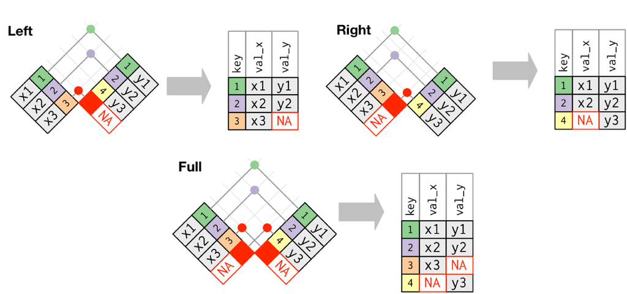

### dplyr::left_join

```r
dplyr::left_join(new_splicing_data, splicing_data_count, by="Event_ID")
```

```
##   Event_ID PSI_value Group Peak count
## 1 ENSG1_AB       0.1     A   NA    43
## 2 ENSG2_CD       0.2     B    5    54
## 3 ENSG3_EF       0.3     B   NA    72
## 4 ENSG4_GH       0.4     A    9    26
## 5 ENSG5_IJ       1.0     A   NA    NA
```

### dplyr::right_join

```r
dplyr::right_join(new_splicing_data, splicing_data_count, by="Event_ID")
```

```
##   Event_ID PSI_value Group Peak count
## 1 ENSG1_AB       0.1     A   NA    43
## 2 ENSG2_CD       0.2     B    5    54
## 3 ENSG3_EF       0.3     B   NA    72
## 4 ENSG4_GH       0.4     A    9    26
```

# The Power of `%>%` (Pipe Operator)

Revolutionize your coding style with the **`%>%`** operator.

[figure not shown]

```r
new_splicing_data %>% select(Event_ID)
```

```
##   Event_ID
## 1 ENSG1_AB
## 2 ENSG2_CD
## 3 ENSG3_EF
## 4 ENSG4_GH
## 5 ENSG5_IJ
```

### dplyr::mutate()

```r
# Transform data in dataframe
new_splicing_data %>% mutate(new_PSI_value = 10*PSI_value)
```

```
##   Event_ID PSI_value Group Peak new_PSI_value
## 1 ENSG1_AB       0.1     A   NA             1
## 2 ENSG2_CD       0.2     B    5             2
## 3 ENSG3_EF       0.3     B   NA             3
## 4 ENSG4_GH       0.4     A    9             4
## 5 ENSG5_IJ       1.0     A   NA            10
```

### dplyr::filter()

```r
new_splicing_data %>% filter(PSI_value > 0.2)
```

```
##   Event_ID PSI_value Group Peak
## 1 ENSG3_EF       0.3     B   NA
## 2 ENSG4_GH       0.4     A    9
## 3 ENSG5_IJ       1.0     A   NA
```

| dplyr Verb | What it Does |
| --- | --- |
| `group_by` | groups the data based on the specified column. |
| `summarize` | Compute summary statistics for the data. |

### dplyr::group_by() & dplyr::summarise()

```r
new_splicing_data %>%
  group_by(Group) %>%
  summarise(
    mean_value = mean(PSI_value)
  )
```

```
## # A tibble: 2 × 2
##   Group mean_value
##   <chr>      <dbl>
## 1 A           0.5
## 2 B           0.25
```

# Write data

```r
write.csv(new_splicing_data, 'new_splicing_data.csv')
```

# Real World Problem for Self Learning

Join our coding challenge! Craft the most **well-structured**, **reproducible**, and **readable code** for analyzing qPCR data using tidyverse packages. Your winning code will be showcased with a shout-out on Slack, and you’ll receive an exciting prize in the next session.

Submission till March 2

cq_values.csv table contains well-specific quantification values (Cq) from qPCR

```
##   Well    Cq
## 1  A01 24.63
## 2  A02 21.00
## 3  A03 19.63
## 4  A04  4.60
## 5  A05 18.44
## 6  A06 24.26
```

plate_view.csv table provides corresponding information about genes and samples associated with each well

```r
head(df_plate)
```

```
##   X     X.1       X1       X2       X3       X4       X5       X6       X7
## 1 A Content   Gene 1   Gene 2   Gene 3   Gene 4   Gene 5   Gene 6   Gene 7
## 2 A  Sample Sample_A Sample_A Sample_A Sample_A Sample_A Sample_A Sample_A
## 3 A      Cq      NaN      NaN      NaN      NaN      NaN      NaN      NaN
## 4 A              NaN      NaN      NaN      NaN      NaN      NaN      NaN
## 5 B Content   Gene 1   Gene 2   Gene 3   Gene 4   Gene 5   Gene 6   Gene 7
## 6 B  Sample Sample_A Sample_A Sample_A Sample_A Sample_A Sample_A Sample_A
##         X8       X9      X10      X11      X12
## 1   Gene 8   Gene 9  Gene 10  Gene 11  Gene 12
## 2 Sample_A Sample_A Sample_A Sample_A Sample_A
## 3      NaN      NaN      NaN      NaN      NaN
## 4      NaN      NaN      NaN      NaN      NaN
## 5   Gene 8   Gene 9  Gene 10  Gene 11  Gene 12
## 6 Sample_A Sample_A Sample_A Sample_A Sample_A
```